# Drilling and preterm birth, case-control study

David J.X. Gonzalez

This document summarizes data and findings from the study, *Oil and gas drilling and risk of spontaneous preterm birth in the San Joaquin Valley, California*, by David J.X. Gonzalez, Allison R. Sherris, Wei Yang, Amy Padula, David K. Stevenson, Michael Baiocchi, Mark R. Cullen, and Gary M. Shaw.

# 1 Project Summary

# 2 Methods

*Project Workflow*

1. Gather data from California on (a) births from OSHPD and (b) oil and gas wells from DOGGR
2. Prepare data for analyses
3. For each birth and each month of gestation (B1-P10), assess exposure to wells by generating an exposure index inverse distance squared weighting
4. Divide exposure into categories: no exposure, and exposure tertiles
5. Conduct primary analyses using logistic regression models to assess the association between preterm birth and exposure; compare most births (highest tertile) to unexposed births; includes unadjusted models; models adjusted for observed maternal covariates; and models adjusted for observed maternal covariates and birth yearr
6. Conduct sensitivity analyses
1. Test assumptions in the exposure assessment
2. Stratify on observed maternal covariates
3. Consider exposure by trimester
4. Assess association between preterm birth and exposure to abandoned wells
7. Visualize results
8. Prepare figures and tables for manuscript, as well as supplementary materials

# 3 Data

## 3.1 Data Description

*Birth Outcomes Data*

Next, we linked the cases and controls with discharge data from the Office of Statewide Health and Planning (OSHPD). Linkage was successful for 220,137 (99%) controls and 72,907 (99%) cases. We removed cases where preterm birth may have been medically indicated and excluded births with the following maternal comorbidities, owing to the assumption that their underlying etiologies would be different: pre-gestational diabetes, gestational diabetes, gestational hypertension, preeclampsia/eclampsia, and chronic hypertension (except for the 20 to 23-week group). This resulted in a final dataset comprising 225,374 births, including 27,913 spontaneous preterm cases and 197,461 term controls. Following definitions previously used by Shaw et al. (2018), we divided preterm birth into three categories based on gestational age: 20-27 weeks (very early), 28-31 weeks (early), and 32-36 weeks (moderate).

*Oil and Gas Wells Data*

We obtained data on oil and gas wells from the California Department of Conservation, Division of Oil, Gas, and Geothermal Resources (DOGGR GIS Unit 2019). The DOGGR dataset includes locations and records for all wells in California and is updated daily. The data used in this study were obtained in April 2018. Records are available for well type, status, and development dates, including date of spudding (initial drilling) and completion (when the well is ready for production). For the purposes of the current study, we compiled a dataset including wells drilled during the study period in the eight study counties plus a 15 km buffer, to account for residences along county borders. We identified 11,972 unique wells that met the above criteria.

## 3.2 Data Exploration

### 3.2.1 Birth Outcomes Data

*Plot. Infant sex by birth year*

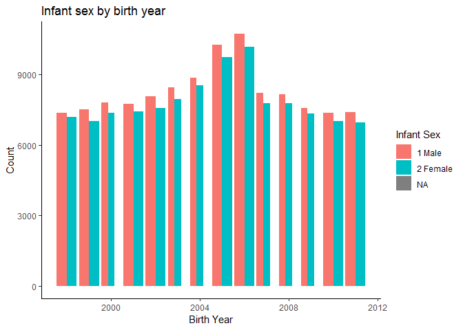

*Plot. Preterm category by birth year*

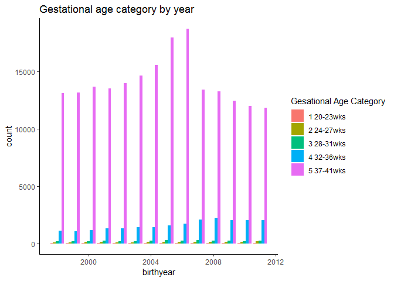

*Plot. Maternal age by preterm birth category*

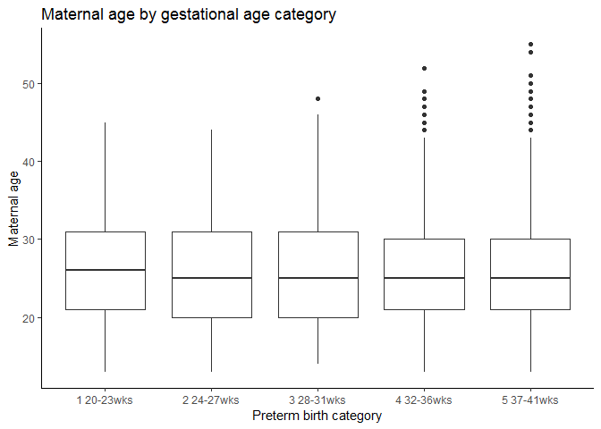

*Plot. Maternal race by preterm birth category*

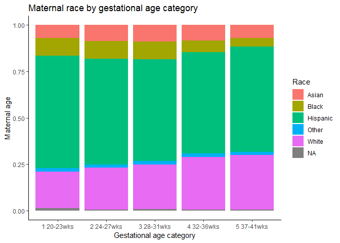

*Plot. Maternal education by gestational age category*

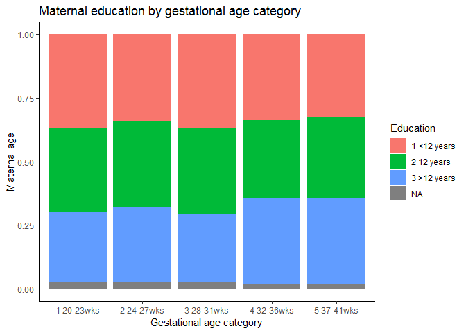

### 3.2.2 Oil and Gas Wells Data

**Plot. Frequency of spud dates.**

Note: it may be helpful to make an additional plot showing spudding by month-year

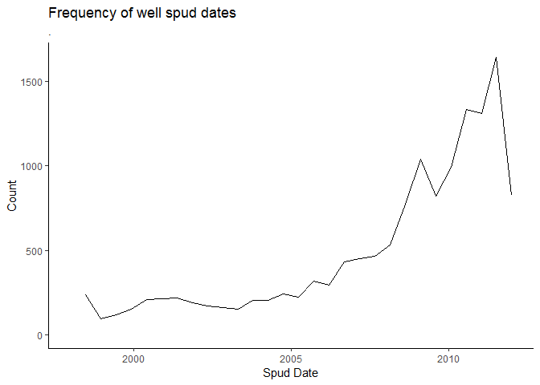

**Plot. Distribution of spud dates by month**

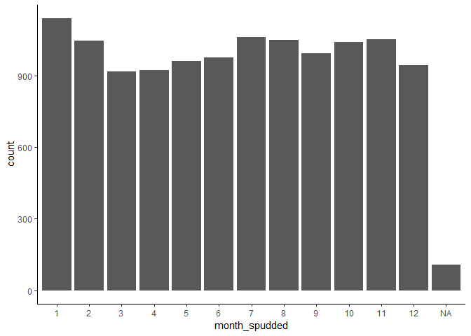

**Plot. Distribution of spud dates by month, stratified by county.**

[figure not shown]

*Plot. Distribution of completion dates by month.*

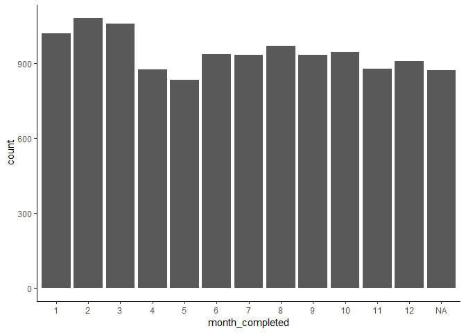

**Plot. Distribution of completion dates by month, stratified by county.**

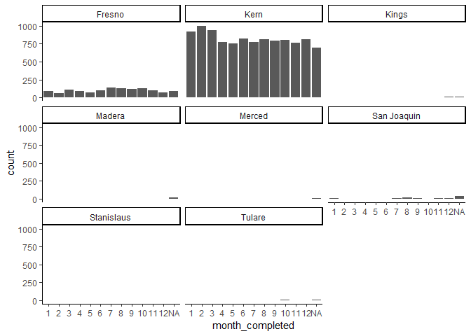

**Plot. Distribution of spud dates by year.**

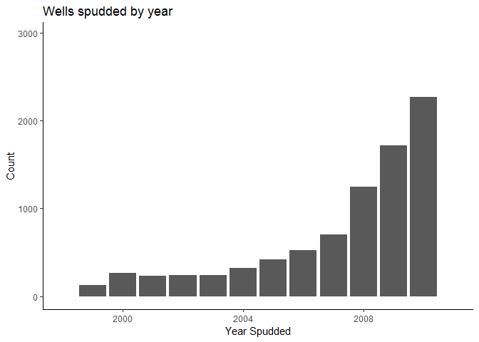

**Plot. Distribution of spud dates by month, stratified by year.**

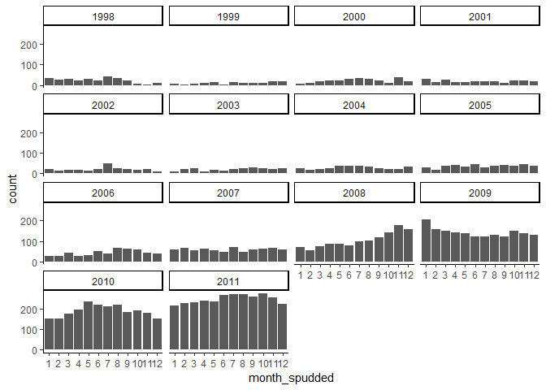

**Plot. Distribution of completion dates by month, stratified by year.**

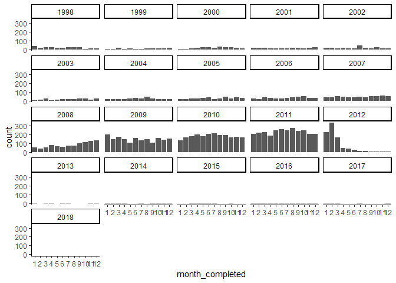

**Plot. Count of wells by county, study region**

Restricted to the eight study counties

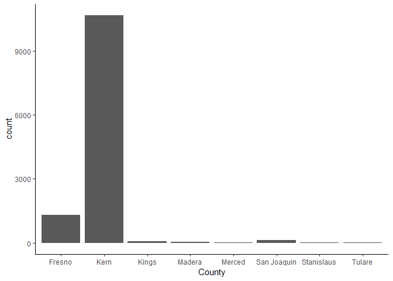

*Plot. Count of wells by county, study region plus buffer*

This includes the eight study counties plus neighboring counties, due to the 15 km buffer placed around the study counties to account for exposure for women who may live along the border of the study counties.

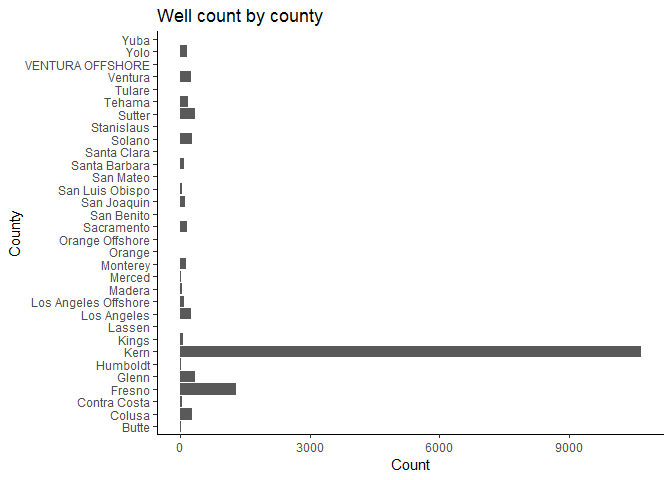

Proportion of wells in each study county that were hydraulically fractured. Note that, as shown above, there are many more wells in Kern County than there are in Kings or Madera Counties.

*Plot. Hydraulically fractured wells by year, study region*

[figure not shown]

# 4 Results

## 4.1 Descriptive Results

*Mean and SD of the cumulative IDW exposure index stratified by quartile, primary analysis*

42786 exposed births

```
## # A tibble: 4 x 3
##   Exposure_Quartile `mean(IDW_Exposure_Index)` `sd(IDW_Exposure_Index)`
##               <dbl>                      <dbl>                    <dbl>
## 1                 0                     0                        0
## 2                 1                     0.0359                   0.0235
## 3                 2                     0.290                    0.161
## 4                 3                     3.79                     6.33
```

*Mean and SD of the cumulative IDW exposure index stratified by quartile, sensitivity analysis A1*

5350 exposed births

```
## # A tibble: 4 x 3
##   Exposure_Quartile `mean(IDW_Exposure_Index)` `sd(IDW_Exposure_Index)`
##               <dbl>                      <dbl>                    <dbl>
## 1                 0                      0                        0
## 2                 1                      0.295                    0.164
## 3                 2                      1.31                     0.304
## 4                 3                      6.00                    12.2
```

*Plot. Distribution of the exposure index, continuous*

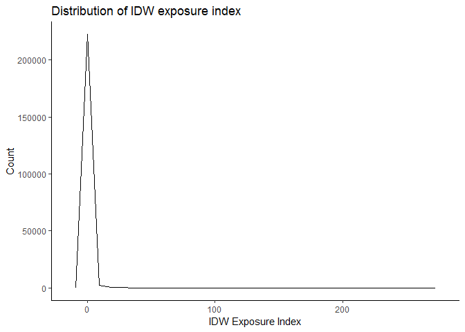

## 4.2 Primary Analyses

*Figure. Primary analysis results*

Unadjusted (crude) and adjusted odds ratios (ORs) and 95% confidence intervals (CIs) for odds of preterm birth with an interquartile range increase in exposure to oil and gas drilling, stratified by gestational age category.

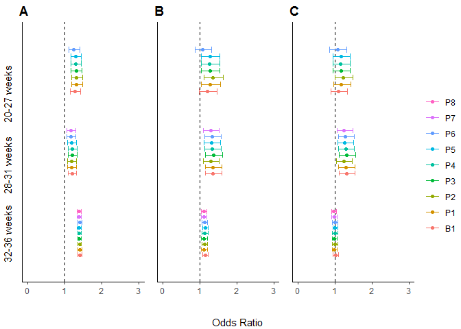

**Figure. Primary analysis results, exposure by trimester**

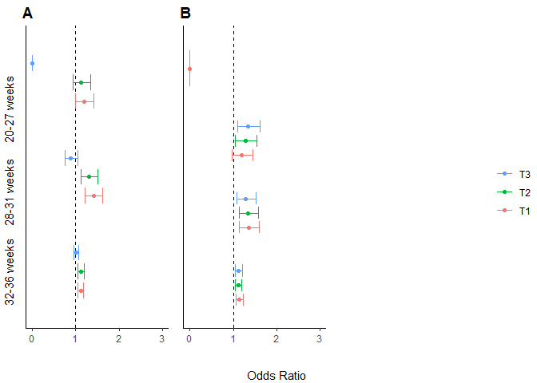

## 4.3 Sensitivity Analyses

### 4.3.1 Sensitivity A: Test exposure assessment assumptions

**Sensitivity A1-a: 3 km radius, IDW squared**

**Table. Observed maternal characteristics by exposure quartile**

| Characteristic | 0, no exposure | 1, low | 2, medium | 3, high |
| --- | --- | --- | --- | --- |
| **n** | 220024 | 1784 | 1783 | 1783 |
| **Maternal Age**, years (mean +/- SD) | 26 +/- 6 | 26.2 +/- 5.9 | 25.6 +/- 6 | 25.9 +/- 6 |
| **Maternal Race (%)** |  |  |  |  |
| *Asian* | 7.2 | 6.6 | 6.2 | 4.5 |
| *Black* | 4.8 | 5.9 | 5.1 | 4 |
| *Hispanic* | 56.9 | 48.7 | 51.1 | 48.7 |
| *White, Non-Hispanic* | 29 | 36.7 | 34.8 | 40.2 |
| *Other* | 1.5 | 1.5 | 2.1 | 1.7 |
| *Missing* | 0 | 0.7 | 0.8 | 0.8 |
| **Maternal Education** |  |  |  |  |
| *< 12 years* | 32.9 | 27.4 | 30.5 | 27 |
| *12 years* | 31.7 | 32.9 | 36.2 | 37.1 |
| *> 12 years* | 33.8 | 36.2 | 29.5 | 31.9 |
| *Missing* | 0 | 3.5 | 3.8 | 4 |
| **Parity** |  |  |  |  |
| *1* | 35 | 35.7 | 35.1 | 36 |
| *2 or more* | 64.9 | 64.2 | 64.8 | 63.8 |
| *Missing* | 0.1 | 0.1 | 0.1 | 0.2 |
| **Infant Sex (% female)** | 48.7 | 48.9 | 50.9 | 48.8 |

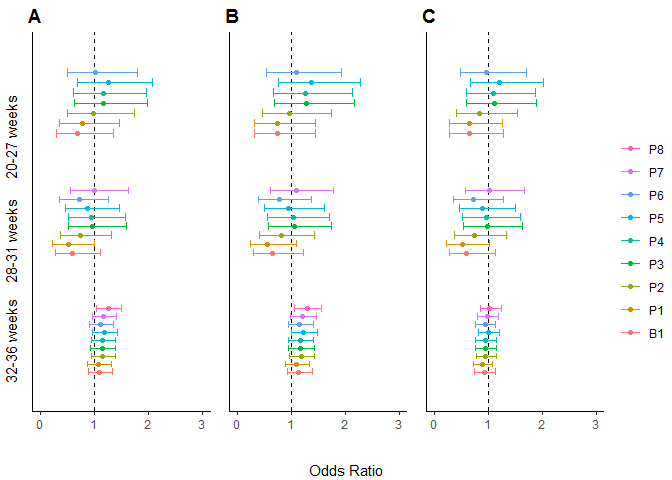

Figure. Results from sensitivity analysis A1, (A) unadjusted, (B) adjusted for observed maternal covariates, and (C) adjusted for observed maternal covariates and birth yearr.

**Sensitivity A1-b: 3 km radius, IDW square-root**

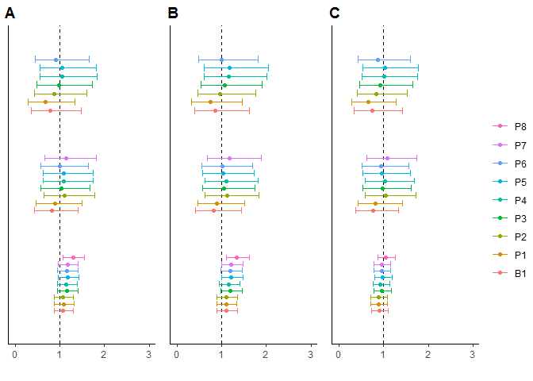

Figure. Results from sensitivity analysis A1, (A) unadjusted, (B) adjusted for observed maternal covariates, and (C) adjusted for observed maternal covariates and birth yearr.

**Sensitivity A1-c: 3 km radius, IDW direct**

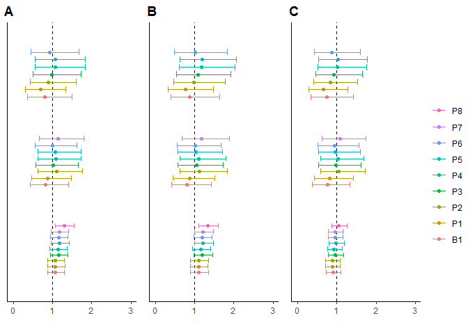

**Sensitivity A1-d: 3 km radius, IDW direct, exposure by trimester**

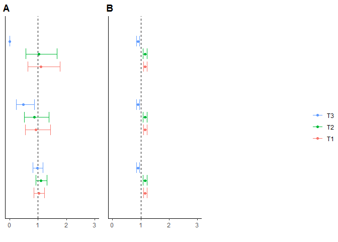

**Sensitivity A2: 5 km radius, IDW squared**

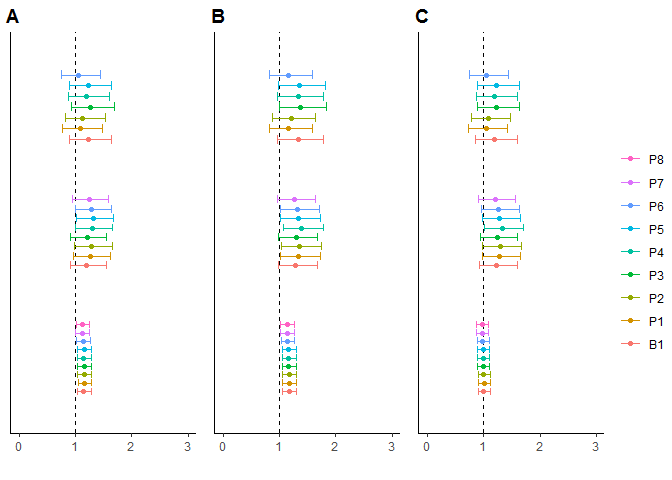

Figure. Results from sensitivity analysis A2, (A) unadjusted, (B) adjusted for observed maternal covariates, and (C) adjusted for observed maternal covariates and birth yearr.

**Sensitivity A3: 15 km radius, IDW squared**

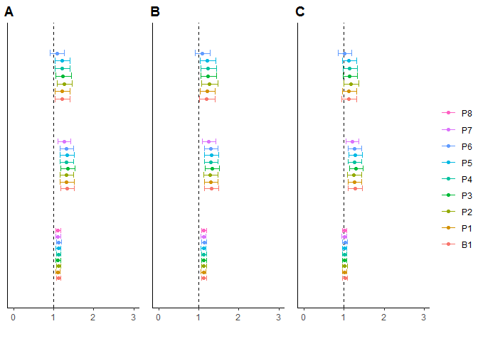

Figure. Results from sensitivity analysis A3, (A) unadjusted, (B) adjusted for observed maternal covariates, and (C) adjusted for observed maternal covariates and birth yearr.

**Sensitivity A4: 10 km radius, IDW square-root**

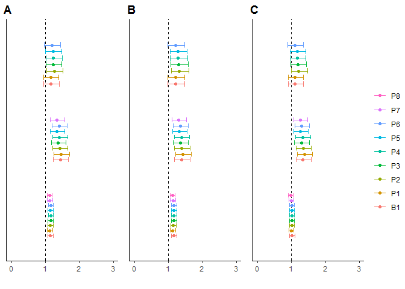

Figure. Results from sensitivity analysis A4, (A) unadjusted, (B) adjusted for observed maternal covariates, and (C) adjusted for observed maternal covariates and birth yearr.

*Sensitivity A5: 10 km radius, IDW power 1*

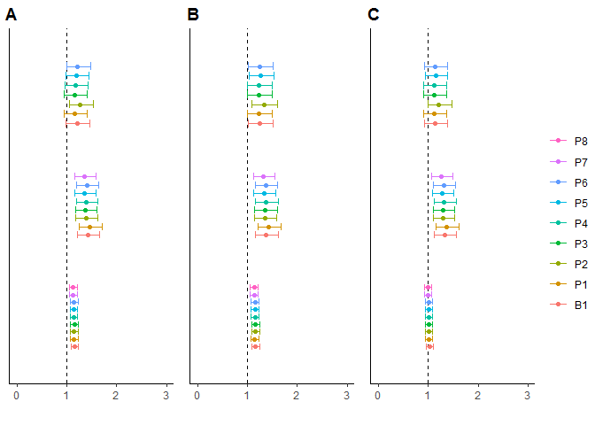

Figure. Results from sensitivity analysis A5, (A) unadjusted, (B) adjusted for observed maternal covariates, and (C) adjusted for observed maternal covariates and birth yearr.

### 4.3.2 Sensitivity B: Stratified on observed covariates

*Distribution of exposure by gestational age category, stratified on race/ethnicity*

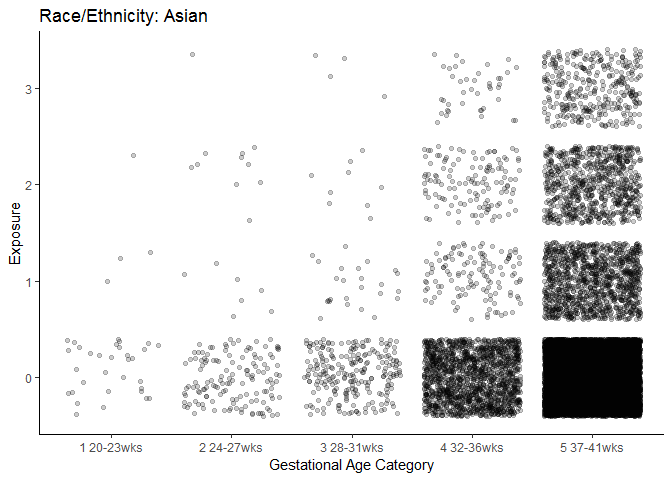

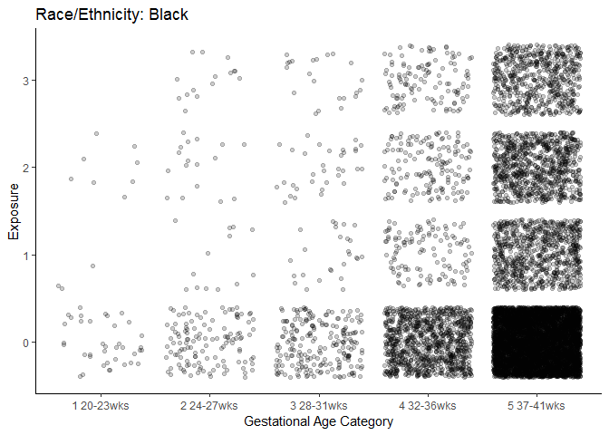

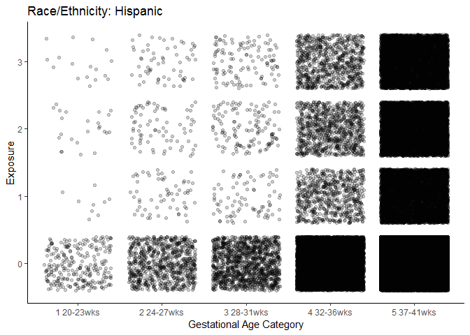

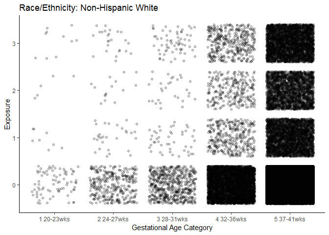

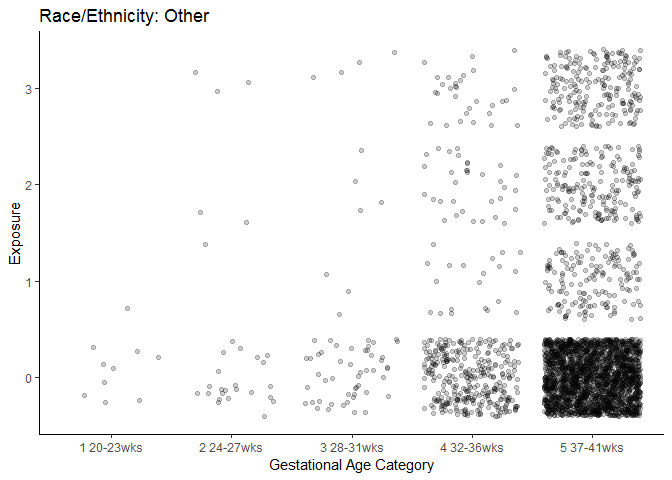

**Results**

*Race*

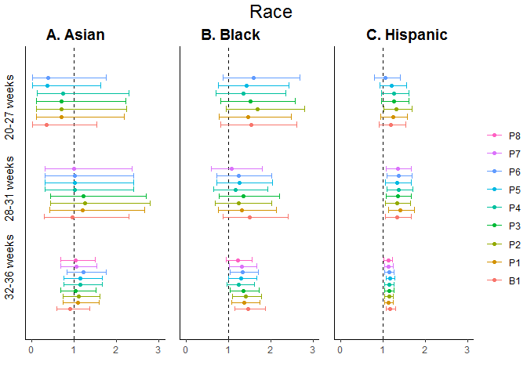

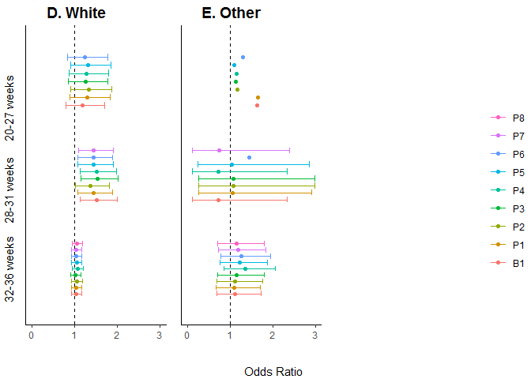

*Educational Attainment*

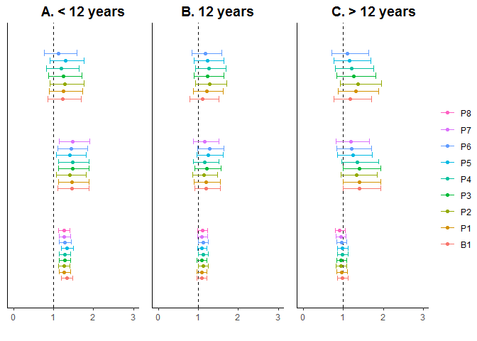

*Parity*

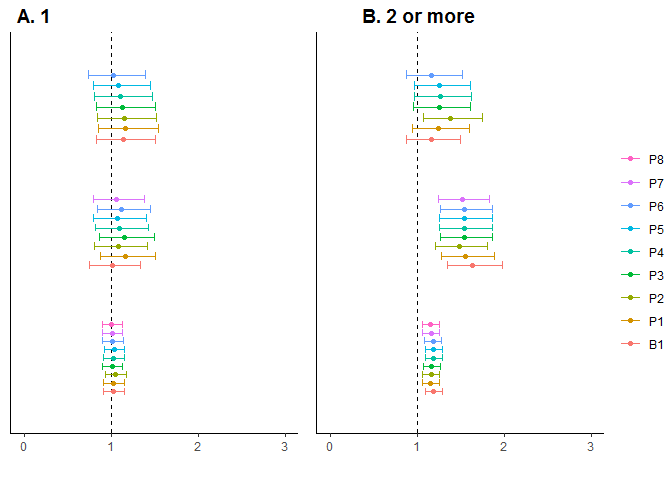

*Age*

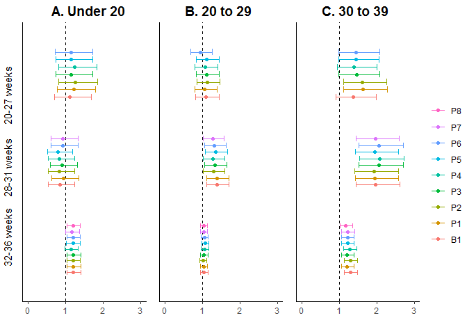

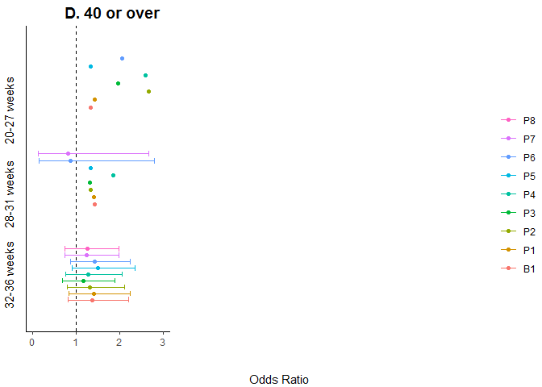

```
## integer(0)
```

### 4.3.3 Sensitivity C: Stratified on exposure (Trimester 1, 2, 3)

*Exposure by trimester*

The approach to the trimester analysis was different than the approach used for the above analyses. First, I identifed births that were only exposed in the first (P1-P3), second (P4-P6), and third (P7-P10) trimesters. Several thousand births met this criteria, see distributions below

*Births exposed only in 1st trimester:*

```
##      ptb_category
##  1 20-23wks:  13
##  2 24-27wks:  48
##  3 28-31wks:  56
##  4 32-36wks: 387
##  5 37-41wks:3288
```

*Births exposed only in 2nd trimester:*

```
##      ptb_category
##  1 20-23wks:  10
##  2 24-27wks:  33
##  3 28-31wks:  50
##  4 32-36wks: 249
##  5 37-41wks:2314
```

*Births exposed only in 3rd trimester:*

```
##      ptb_category
##  1 20-23wks:   0
##  2 24-27wks:   4
##  3 28-31wks:  22
##  4 32-36wks: 410
##  5 37-41wks:4844
```

**Table. Characteristics of study population stratified on trimester of exposure**

This table compares observed maternal characteristics stratified by trimester of exposure. Trimesters 1, 2, and 3 births were exposed only in their respective trimesters. Multiple were exposed in more than 1 trimester. Unexposed were not exposed during gestaiton.

| Characteristic | Trimester 1 | Trimester 2 | Trimester 3 | Multiple | Unexposed |
| --- | --- | --- | --- | --- | --- |
| **n** | 3792 | 2656 | 5280 | 29996 | 182588 |
| **Maternal Age**, years (mean +/- SD) | 26.2 +/- 6 | 26.4 +/- 6.1 | 26.3 +/- 6.1 | NA +/- NA | NA +/- NA |
| **Maternal Race (%)** |  |  |  |  |  |
| *Asian* | 9.8 | 10.3 | 9.6 | 4.7 | 7.4 |
| *Black* | 7.5 | 7.3 | 6.5 | 6.5 | 4.3 |
| *Hispanic* | 54.1 | 53.2 | 54.9 | 60.4 | 56.3 |
| *White, Non-Hispanic* | 26.9 | 27.5 | 27.4 | 25.9 | 29.8 |
| *Other* | 1.3 | 1.1 | 1.3 | 1.7 | 1.5 |
| *Missing* | 0.4 | 0.6 | 0.3 | 0 | 0.5 |
| **Maternal Education** |  |  |  |  |  |
| *< 12 years* | 29.9 | 29.3 | 32.1 | 35 | 32.5 |
| *12 years* | 33 | 33.3 | 32.4 | 34.1 | 31.3 |
| *> 12 years* | 34.9 | 34.8 | 33.1 | 27.2 | 34.9 |
| *Missing* | 1.8 | 2.6 | 2.4 | 3.7 | 1.3 |
| **Parity** |  |  |  |  |  |
| *1* | 35.6 | 34.8 | 34.8 | 35.3 | 35 |
| *2 or more* | 64.3 | 65.1 | 65.2 | 64.6 | 65 |
| *Missing* | 0.1 | 0.1 | 0.1 | 0.1 | 0.1 |
| **Infant Sex (% female)** | 49.3 | 49.7 | 49.9 | 49 | 48.6 |

[figure not shown]

### 4.3.4 Sensitivity D: Abandoned Wells

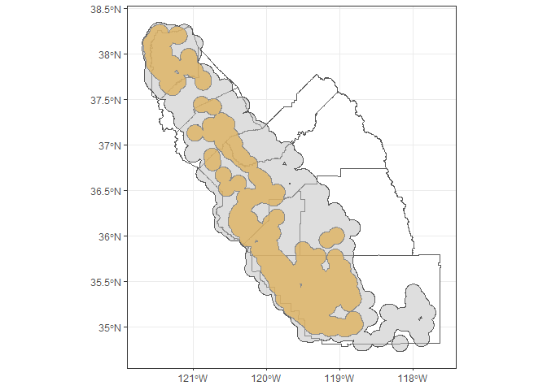

### 4.3.5 Sensitivity E: Births 3-10 km from nearest well

[figure not shown]

# 5 Manuscript Materials

Figures, tables, and supplementary materials for the manuscript.

## 5.1 Figures

### 5.1.1 Figure 1

Map of study region.

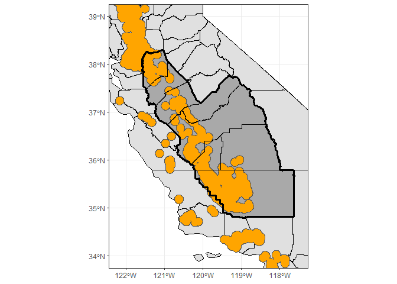

### 5.1.2 Figure 2

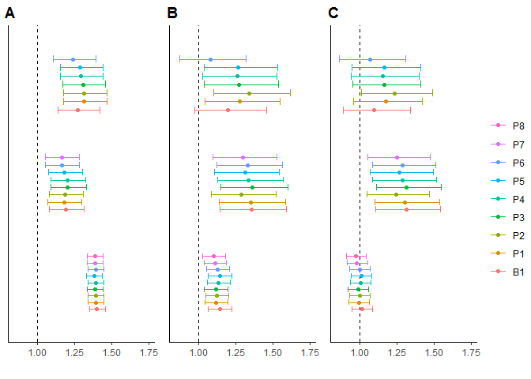

Figure 2. (A) Unadjusted and (B) adjusted for observed maternal covariates.

## 5.2 Tables

### 5.2.1 Table 1. Characteristics of study population, comparing births stratified by dstance to the nearest well

[output not shown]

## 5.3 Supplementary

### 5.3.1 Table S1. Compare characteristics by gestational age category

| Characteristic | 20-27 weeks | 28-31 weeks | > 32-36 weeks | 37-41 weeks |
| --- | --- | --- | --- | --- |
| **n** | 2307 | 3098 | 22508 | 197461 |
| **Maternal Age**, years (mean +/- SD) | 25.99 +/- 6.65 | 25.74 +/- 6.57 | 26.07 +/- 6.28 | 26.04 +/- 5.92 |
| **Maternal Race (%)** |  |  |  |  |
| *Asian* | 8.32 | 8.84 | 8.25 | 7.06 |
| *Black* | 9.45 | 9.55 | 6.27 | 4.46 |
| *Hispanic* | 57.91 | 54.94 | 54.75 | 56.99 |
| *White, Non-Hispanic* | 22.06 | 24.11 | 28.35 | 29.42 |
| *Other* | 1.69 | 1.94 | 1.83 | 1.5 |
| *Missing* | 0.82 | 0.61 | 0.55 | 0.57 |
| **Maternal Education** |  |  |  |  |
| *< 12 years* | 34.63 | 37.06 | 33.66 | 32.6 |
| *12 years* | 33.85 | 33.8 | 31.02 | 31.77 |
| *> 12 years* | 29.04 | 26.82 | 33.58 | 34 |
| *Missing* | 3.12 | 2.32 | 1.75 | 1.64 |
| **Parity** |  |  |  |  |
| *1* | 44.34 | 38.06 | 35.79 | 34.75 |
| *2 or more* | 55.53 | 61.75 | 64.12 | 65.15 |
| *Missing* | 0.13 | 0.19 | 0.09 | 0.1 |
| **Infant Sex (% female)** | 42.96 | 41.54 | 44.9 | 49.37 |